# Exam 1

2025-02-27

```r
library(tidyverse)
library(ISLR2)
```

# Exam 1

## Instructions (*Please Read!*)

- This exam is set up so that even if you get stuck on one part there are opportunities to get points on the other parts, so consider jumping ahead if you feel like you aren’t making progress and then come back later if you have time.
- This part of the exam has 60 total points available. Each question is worth 5 points. Partial credit is available, so it is better to at least put *something* rather than leaving a question blank.
- **Important note about using online resources:** This exam is “open internet”. That means that you can look up documentation, google how to accomplish certain tasks, access old ICAs, etc. However, the use of any person-to-person communication or communication with generative AI such as ChatGPT is absolutely not acceptable. If you are seen accessing your email, using ChatGPT, using a messaging service, or accessing any sort of collaborative cloud storage or document software (e.g. Google Documents), you will be at risk of receiving a zero on the exam.
- Keep your eyes on your screen! This exam is designed to give you the opportunity to show the instructor what you can do and you should hold yourself accountable for maintaining a high level of academic integrity. If any of the instructors observe suspicious behavior, you will, again, risk receiving a zero.
- You are encouraged to check the code chunks and test your code in RStudio.

### Section 1

#### Question 1.1

Write the R code to create a vector called `Oceania` that contains the 14 countries in Oceania. Use the given vectors `Oceania1` and `Oceania2` in your solution.

*Oceania1 <- c(“Australia”, “Fiji”, “Kiribati”, “Marshall Islands”, “Micronesia”, “Nauru”, “New Zealand”)*

*Oceania2 <- c(“Palau”, “Papua New Guinea”, “Samoa”, “Solomon Islands”, “Tonga”, “Tuvalu”,“Vanuatu”)*

```r
Oceania1 <- c("Australia", "Fiji", "Kiribati", "Marshall Islands", "Micronesia", "Nauru", "New Zealand")
Oceania2 <- c("Palau", "Papua New Guinea", "Samoa", "Solomon Islands", "Tonga", "Tuvalu","Vanuatu")

# Your code for Q1.1 below
Oceania <- c(Oceania1,Oceania2)
Oceania
```

```
##  [1] "Australia"        "Fiji"             "Kiribati"         "Marshall Islands"
##  [5] "Micronesia"       "Nauru"            "New Zealand"      "Palau"
##  [9] "Papua New Guinea" "Samoa"            "Solomon Islands"  "Tonga"
## [13] "Tuvalu"           "Vanuatu"
```

#### Question 1.2

You are given the following vector, `count.by.three` below. Using R code and the supplied vector, extract the 13th-20th elements.

```r
count.by.three <- seq(12,99,3)

# Your code for Q1.2 below
count.by.three[13:20]
```

```
## [1] 48 51 54 57 60 63 66 69
```

#### Question 1.3

This question will use the built-in `CO2` dataset. Add a new column to the `CO2` data set called `uptake.per.conc`, which contains the uptake divided by the concentration for each observation.

```r
# Your code for Q1.3 below
head(CO2)
```

```
##   Plant   Type  Treatment conc uptake
## 1   Qn1 Quebec nonchilled   95   16.0
## 2   Qn1 Quebec nonchilled  175   30.4
## 3   Qn1 Quebec nonchilled  250   34.8
## 4   Qn1 Quebec nonchilled  350   37.2
## 5   Qn1 Quebec nonchilled  500   35.3
## 6   Qn1 Quebec nonchilled  675   39.2
```

```r
CO2 %>%
  mutate(uptake.per.conc = uptake / conc)
```

```
##    Plant        Type  Treatment conc uptake uptake.per.conc
## 1    Qn1      Quebec nonchilled   95   16.0      0.16842105
## 2    Qn1      Quebec nonchilled  175   30.4      0.17371429
## 3    Qn1      Quebec nonchilled  250   34.8      0.13920000
## 4    Qn1      Quebec nonchilled  350   37.2      0.10628571
## 5    Qn1      Quebec nonchilled  500   35.3      0.07060000
## 6    Qn1      Quebec nonchilled  675   39.2      0.05807407
## 7    Qn1      Quebec nonchilled 1000   39.7      0.03970000
## 8    Qn2      Quebec nonchilled   95   13.6      0.14315789
## 9    Qn2      Quebec nonchilled  175   27.3      0.15600000
## 10   Qn2      Quebec nonchilled  250   37.1      0.14840000
## 11   Qn2      Quebec nonchilled  350   41.8      0.11942857
## 12   Qn2      Quebec nonchilled  500   40.6      0.08120000
## 13   Qn2      Quebec nonchilled  675   41.4      0.06133333
## 14   Qn2      Quebec nonchilled 1000   44.3      0.04430000
```

[output cut: 70 more lines]

```r
# or

CO2$uptake.per.conc <- CO2$uptake / CO2$conc
```

### Section 2

The following questions are based on the dataset `titanic3` from the PASWR package. The data consists of demographic and traveling information for the 1,309 of the Titanic passengers. **Note: you may need to install the `PASWR` package for it to load in properly. If it still doesn’t load in, you can load in the supplied Rdata file.**

```r
library(PASWR)
head(titanic3)
```

```
##   pclass survived                            name    sex     age sibsp parch
## 1    1st        1   Allen, Miss. Elisabeth Walton female 29.0000     0     0
## 2    1st        1  Allison, Master. Hudson Trevor   male  0.9167     1     2
## 3    1st        0    Allison, Miss. Helen Loraine female  2.0000     1     2
## 4    1st        0 Allison, Mr. Hudson Joshua Crei   male 30.0000     1     2
## 5    1st        0 Allison, Mrs. Hudson J C (Bessi female 25.0000     1     2
## 6    1st        1             Anderson, Mr. Harry   male 48.0000     0     0
##   ticket     fare   cabin    embarked boat body                       home.dest
## 1  24160 211.3375      B5 Southampton    2   NA                    St Louis, MO
## 2 113781 151.5500 C22 C26 Southampton   11   NA Montreal, PQ / Chesterville, ON
## 3 113781 151.5500 C22 C26 Southampton        NA Montreal, PQ / Chesterville, ON
## 4 113781 151.5500 C22 C26 Southampton       135 Montreal, PQ / Chesterville, ON
## 5 113781 151.5500 C22 C26 Southampton        NA Montreal, PQ / Chesterville, ON
## 6  19952  26.5500     E12 Southampton    3   NA                    New York, NY
```

#### Question 2.1

Use dplyr functions to find the mean age of passengers for each class.

```r
# Your code for Q2.1 below

titanic3 %>%
  group_by(pclass) %>%
  summarise(mean_perclass = mean(age,na.rm = TRUE))
```

```
## # A tibble: 3 × 2
##   pclass mean_perclass
##   <fct>          <dbl>
## 1 1st             39.2
## 2 2nd             29.5
## 3 3rd             24.8
```

#### Question 2.2

Use R code to find the number of unique lifeboats that were used by survivors. Hint: The lifeboat number of a survivor can be found in the `boat` column.

```r
# Your code for Q2.2 below
number_lifeBoats <- titanic3 %>%
  group_by(boat) %>%
  summarise(count = n())

number_lifeBoats
```

```
## # A tibble: 28 × 2
##    boat      count
##    <fct>     <int>
##  1 ""          823
##  2 "1"           5
##  3 "10"         29
##  4 "11"         25
##  5 "12"         19
##  6 "13"         39
##  7 "13 15"       2
##  8 "13 15 B"     1
##  9 "14"         33
## 10 "15"         37
## # ℹ 18 more rows
```

#### Question 2.3

Modify the following starter code so that it outputs the following. Note: std_age represents the standard deviation of age.

```
# A tibble: 2 × 4
  sex    missing mean_age std_age
  <fct>    <int> <dbl>    <dbl>
1 female      78  28.7     14.6
2 male       185  30.6     14.3
```

```r
# Modify this code for Q2.3
titanic3 %>%
  group_by(sex) %>%
  summarise(missing = sum(is.na(age)), mean_age = mean(age,na.rm=TRUE), std_age = sd(age,na.rm=TRUE))
```

```
## # A tibble: 2 × 4
##   sex    missing mean_age std_age
##   <fct>    <int>    <dbl>   <dbl>
## 1 female      78     28.7    14.6
## 2 male       185     30.6    14.3
```

### Section 3

This section contains True/False questions about R code. Write your answer in the indicated locations.

#### Question 3.1

The following code chunks will produce the same information.

code 1:

```r
titanic3 %>%
filter(!is.na(age) & !is.na(fare)) %>%
summarise(age = mean(age), fare = mean(fare))
```

```
##        age     fare
## 1 29.85183 36.68608
```

code 2:

```r
titanic4 <- titanic3[!is.na(titanic3$age) & !is.na(titanic3$fare), ]
apply(titanic4[, c(5,9)], 1, mean)
```

[output not shown]

[output cut: 207 more lines]

[output not shown]

True/False? : `False` when you use 1 in apply you are applying that to the rows in the second chunk the first is doing columns

#### Question 3.2

The following two code chunks will provide you with the same information.

code1:

```r
titanic3 %>%
filter(pclass == "2nd") %>%
group_by(survived) %>%
summarise(count = n())
```

```
## # A tibble: 2 × 2
##   survived count
##      <int> <int>
## 1        0   158
## 2        1   119
```

code 2:

```r
table(titanic3$survived[titanic3$pclass == "2nd"])
```

```
##
##   0   1
## 158 119
```

True/False? : `True` gives same answers just in different formats

#### Question 3.3

The dataset in this question `Carseats` comes from the ISLR2 package. You can also load in the dataset using the supplied Rdata file.

The following code snippets produce the same information.

code 1:

```r
Carseats %>%
filter(ShelveLoc=="Medium") %>%
summarise(TotalCarseats=n(), Mean_sale = mean(Sales, na.rm=TRUE), StdDev_sale = sd(Sales, na.rm=TRUE))
```

```
##   TotalCarseats Mean_sale StdDev_sale
## 1           219  7.306575    2.266373
```

code 2:

```r
CarseatsM <- subset(Carseats, Carseats$ShelveLoc=="Medium")
data.frame(TotalCarseats=length(CarseatsM$ShelveLoc), Mean_sale = mean(CarseatsM$Sales), StdDev_sale=sd(CarseatsM$Sales))
```

```
##   TotalCarseats Mean_sale StdDev_sale
## 1           219  7.306575    2.266373
```

True/False? : `True` Same information just given for getting mean,sd, and total

#### Question 3.4

The dataset in this question `Credit` comes from the ISLR2 package.

The following two code snippets produce the same information.

code 1:

```r
Credit %>%
group_by(Married) %>%
summarise(Count=n(), Average_rating=mean(Rating, na.rm=TRUE), StdDev_rating=sd(Rating, na.rm=TRUE))
```

```
## # A tibble: 2 × 4
##   Married Count Average_rating StdDev_rating
##   <fct>   <int>          <dbl>         <dbl>
## 1 No        155           348.          150.
## 2 Yes       245           359.          158.
```

code 2:

```r
CreditM <- subset(Credit, Credit$Married=="Yes")
data.frame(Married = c("No","Yes"), Count=c(length(Credit$Married), length(CreditM$Married)), Average_rating=c(mean(Credit$Rating, na.rm=TRUE), mean(CreditM$Rating, na.rm=TRUE)), StdDev_rating=c(sd(Credit$Rating, na.rm=TRUE), sd(CreditM$Rating, na.rm=TRUE)))
```

```
##   Married Count Average_rating StdDev_rating
## 1      No   400       354.9400      154.7241
## 2     Yes   245       359.4571      157.8901
```

True/False? : `Fale` The counts avg rates and std avgs are different

### Section 4

This section will focus on creating plots in R. You will be given some starter code for each question that you will be responsible for completing to match the referenced images.

#### Question 4.1

In this question you will recreate the following plot from the starter code given. If the image does not render in your notebook, you can view the image by pasting the link in your browser. (https://github.com/hoolagans/STT180_Public/blob/main/Rplot.png?raw=true).

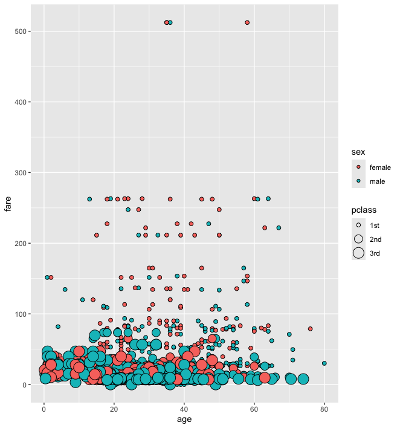

Plot 1

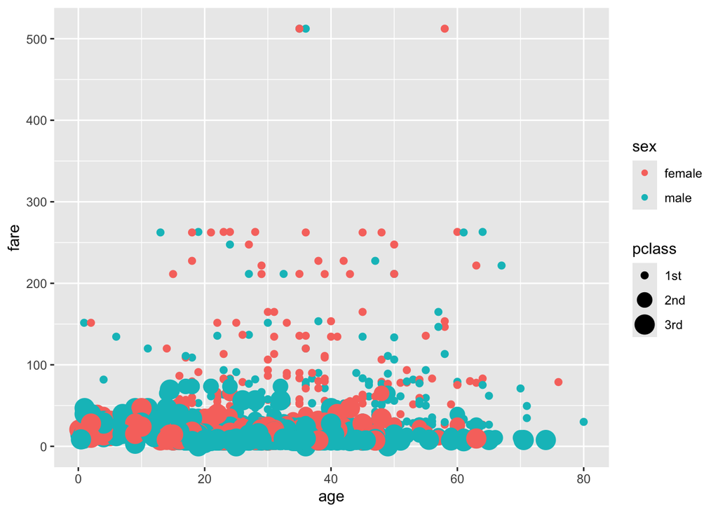

```r
# Modify this starter code to create a plot matching the supplied image
titanic3 %>%
  ggplot(mapping=aes(x=age, y=fare,color = sex,size = pclass)) +
  geom_point()
```

#### Question 4.2

In this question you will recreate the following plot from the starter code given. If the image does not render in your notebook, you can view the image by pasting the link in your browser. (https://github.com/hoolagans/STT180_Public/blob/main/Rplot03.png?raw=true)

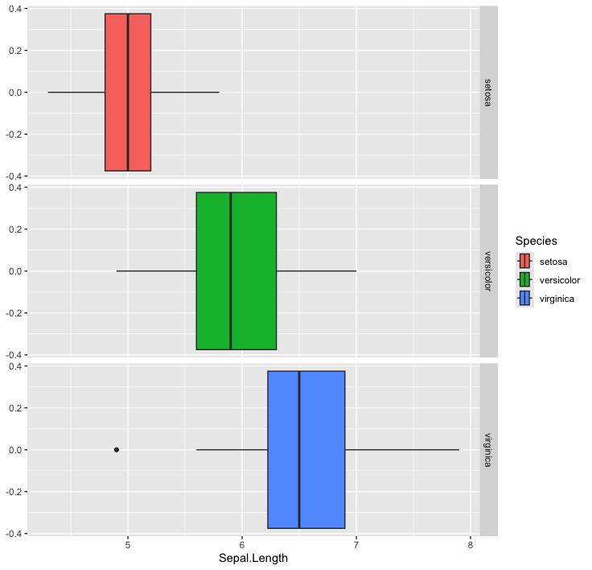

Plot 2

```r
# Modify this starter code to create a plot matching the supplied image
```

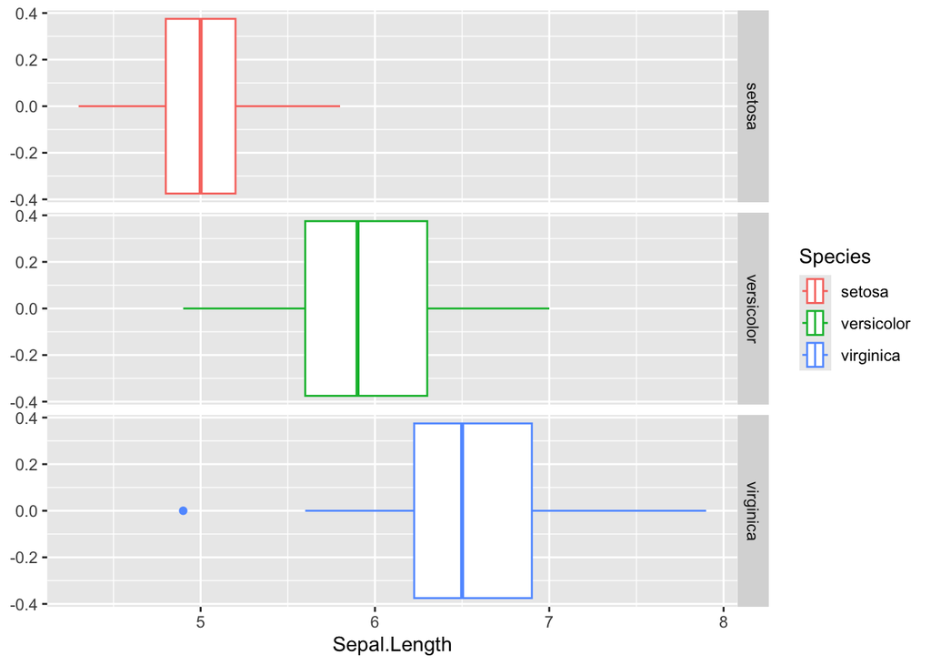

```r
iris %>%
  ggplot(mapping = aes(x=Sepal.Length, color = Species)) +
  geom_boxplot(aes(Sepal.Length)) + # Add a layer to add points or symbols
  facet_grid(rows=vars(Species))
```